# Statistics in R

Manpreet S. Katari

6/28/2020

# Outline

- Introduction to R and tools that enable research.
  - RMarkdown - reproducible research
  - RShiny - web application to share your data and results. No JS required.
- Experimenting with statistics
  - simulations
  - bootstrapping
  - shuffling

# Why R?

- R is a free software environment for statistical computing and graphics.
- It is similar to the S language and environment which was developed at Bell Laboratories (formerly AT&T, now Lucent Technologies) by John Chambers.
- One of R’s strengths is the ease with which well-designed publication-quality plots can be produced, including mathematical symbols and formulae where needed.
- Great care has been taken over the defaults for the minor design choices in graphics, but the user retains full control.

source(http://www.r-project.org/about.html)

# R environment

- an effective data handling and storage facility
- a suite of operators for calculations on arrays, in particular matrices
- a large, coherent, integrated collection of intermediate tools for data analysis
- graphical facilities for data analysis and display either directly at the computer or on hardcopy
- well developed, simple and effective programming language (called “S”) which includes conditionals, loops, user defined recursive functions and input and output facilities.

# Reproducible Research

- Markdowns and Jupyter Notebooks
  - Allow you to save your code and your results in one document.
  - This allows someone to be able to reproduce your results.
  - Easy to remember and use syntax
- RShiny
  - Allow users to change parameters and immediately see results.
  - Let the researcher be in control of their data.
  - Can run locally or be setup on a server.

# Experimenting with Statistics

- Traditional statistical methods require that the data follow some known distribution such as *normal*, *poisson*, *geom*, *negative binomial*, etc, when in reality this may not be true.
- For example the *Student T-test* assumes that the data is normally distributed.
- Such distributions can also be very sensitive to outliers that can skew the model trying to fit the data.
- If we have enough data points, we can empirically determine our statistical significance.

# Case study 1 - Probability of getting an Ace

- Let’s try to determine the number of times we will **fail** before we get an ace. Let’s make a deck of cards and let’s pretend Ace will be the value 1.
- The card that is pulled from the deck is put back so this random sampling with replacement.
- To do this simulation I have created a function whose arguments are:
  - carddeck
  - the number of times it should draw the card
- It then returns the number of times it had to draw a card before getting an Ace.
- If after set number of draws it doesn’t get the Ace, then it will return the number of times it tried.

```r
# create a vector by repeating 1-13 4 times.
carddeck = rep(c(1:13), each=4)

select_Ace = function(carddeck, num_draws) {
  # function will count the number of times it takes to get a 1
  # it will try the number of times defined by num_draws
    card_selected = sample(carddeck, # what to sample from
                           num_draws, # how many to draw
                           replace = T) # can value be selected more than once
    if ( length(which(card_selected==1)) > 0) {
      Ace_selected = min(which(card_selected == 1))
      return(Ace_selected-1)
    } else {
      return(num_draws)
    }
}

#initialize a numeric vector to store results from loop
failures = numeric()

#use this to make results reproducible, not needed for real life use
set.seed(123)

for (i in 1:10000) {
  failures[i]=select_Ace(carddeck, num_draws = 100)
}
```

Check out [R for Data Science](https://r4ds.had.co.nz) for some great tutorials on ggplot.

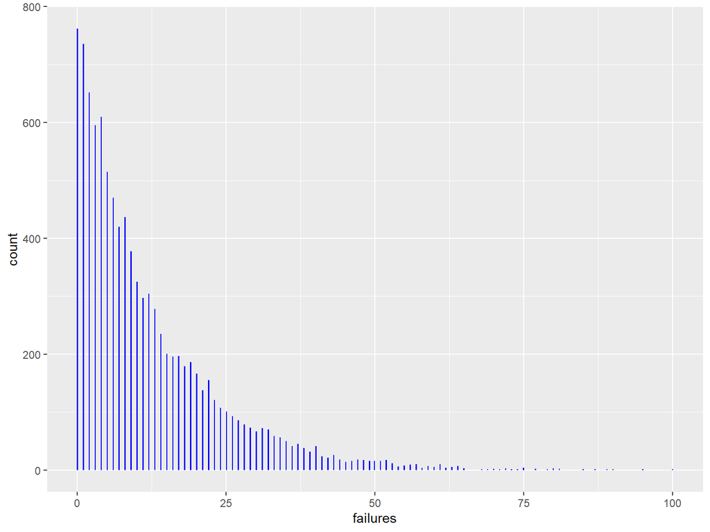

```r
library(ggplot2)
ggplot()+
  geom_histogram(mapping=aes(x=failures),
            bins=500, fill="blue")
```

# The empirical p-value

To simply get our p-values, we can count the number of times we got an Ace within the first 20 draws.

```r
# A logical vector can be converted to 1 = True and 0 = Fales.
# So this is counting the number of times it is T
sum(failures<21)/10000
```

```
## [1] 0.8139
```

The theoretical p-value using the built-in R functions. There are 4 different helper functions for every normal distribution. - *p* - distribution function - *q* - quantile function - *r* - random number generator - *d* - density function

See [R documentatin](https://www.rdocumentation.org/packages/stats/versions/3.6.2/topics/Geometric) for more information.

```r
pgeom(20,1/13)
```

```
## [1] 0.8137931
```

# What about without replacement?

Let’s pretend we are playing poker, what is the probability that one of my cards is an Ace?

```r
poker_cards = function(carddeck, num_draws) {
    card_selected = sample(carddeck,
                           num_draws,
                           replace = F)
    return ( sum(card_selected==1))
}
```

```r
successes = numeric()
set.seed(123)

for (i in 1:10000) {
  successes[i]=poker_cards(carddeck, num_draws = 5)
}
```

Frequency table

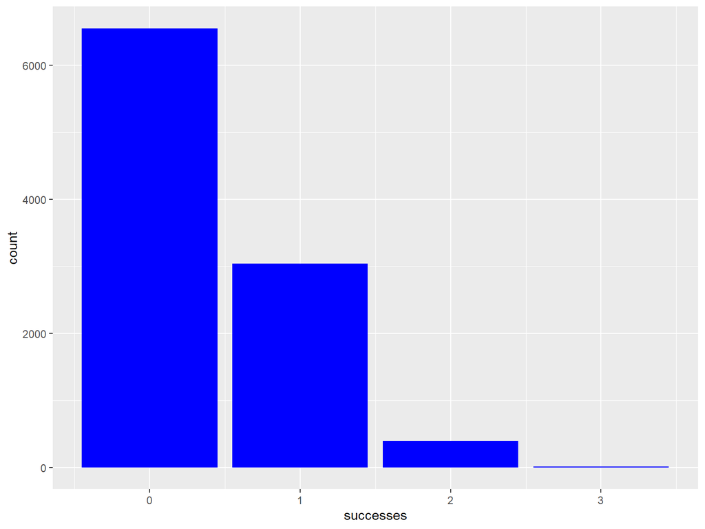

```r
ggplot()+
  geom_bar(mapping=aes(x=successes),
                 fill="blue")
```

```r
table(successes)
```

```
## successes
##    0    1    2    3
## 6549 3040  397   14
```

# The empirical p-value

```r
sum(successes>0)/10000
```

```
## [1] 0.3451
```

Let’s count them

```r
# combn creates all possible combinations.
poker_hands = combn(carddeck, 5)

# see how many different combinations are possible.
# Each combination is in a different column
dim(poker_hands)
```

```
## [1]       5 2598960
```

```r
poker_hands_logic = poker_hands==1

# apply function allows you to apply a specific function to the matrix
# 2 means to each column.
poker_hands_ace = apply(poker_hands_logic, 2, sum)
sum(poker_hands_ace > 0) / ncol(poker_hands)
```

```
## [1] 0.341158
```

# Case Study 2: Marble Selection

- Let’s pretend we have 10,000 marbles in a bag
- 500 of them are blue
- 9,500 are red

### We want to calculate the probability that if we select 300 marbles, we will get 30 or more that are blue.

```r
marbles=c(rep("B", times=500),rep("R", times=9500))
```

One way to do it is to take the function we went over earlier and change it to do the simulation for us.

```r
select_Blue = function(marbles, num_draws, selection) {
  # function will take all the marbles and draw num_draws marbles.
  # you can also pick what to select for.
      marbles_selected = sample(marbles,
                           num_draws,
                           replace = F)
    # which tells you where the match is taking place.
    # so you can simply add the number of positions it found a match.
    blue_selected = length(which(marbles_selected==selection))
    return(blue_selected)
}
```

```r
NumBlues = numeric()
set.seed(123)

for (i in 1:10000) {
  NumBlues[i]=select_Blue(marbles, num_draws = 300, "B")
}

sum(NumBlues >= 30) / 10000
```

```
## [1] 3e-04
```

```r
# if we look closely at the documentation of the phyper, we see that
# when lower.tail = F, then it calculates P(X > x) so if we want 30 and above we need to put
# 29.
phyper(29, 500, 9500, 300, lower.tail = F)
```

```
## [1] 0.0002211093
```

# Expected value

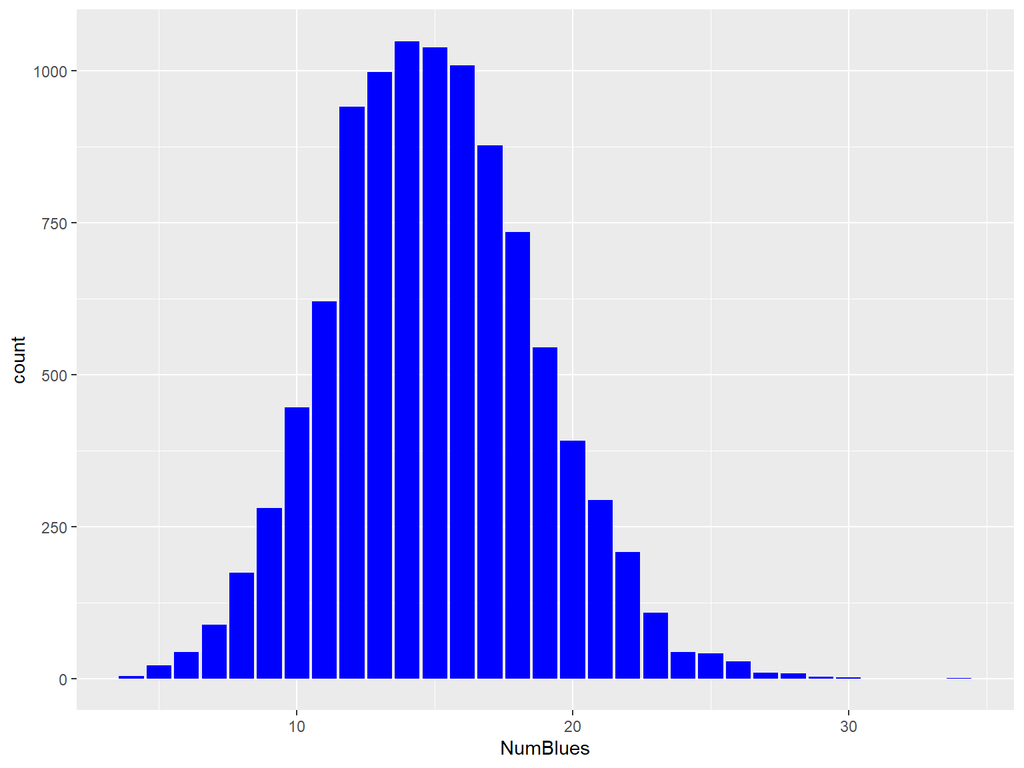

```r
ggplot()+
  geom_bar(mapping=aes(x=NumBlues),
                 bins=500,
                 fill="blue")
```

# Case study 3 - Placebo vs Drug

- The example has been borrowed from *Statistics is Easy*
- Here will discuss a simple case study where the a drug has been provided to 10 random patients ( or test subjects ) and a placebo pill, as a control, was given to 10 other random patients.

### Question: Is there a significant difference between the control subject and the those that were given the drug?

# The Population

Let’s first look at all values as a population.

```r
Placebo = c(54,51,58,44,55,52,42,47,58,46)
Drug = c(54,73,53,70,73,68,52,65,65,60)
```

We can use the *reshape2* library to format our **wide** format to **long** format.

```r
library(reshape2)
datamatrix = cbind(Placebo,Drug)
head(datamatrix)
```

```
##      Placebo Drug
## [1,]      54   54
## [2,]      51   73
## [3,]      58   53
## [4,]      44   70
## [5,]      55   73
## [6,]      52   68
```

```r
datamelt = melt(datamatrix,
                varnames = c("id","treatment"))
datamelt
```

```
##    id treatment value
## 1   1   Placebo    54
## 2   2   Placebo    51
## 3   3   Placebo    58
## 4   4   Placebo    44
## 5   5   Placebo    55
## 6   6   Placebo    52
## 7   7   Placebo    42
## 8   8   Placebo    47
## 9   9   Placebo    58
## 10 10   Placebo    46
## 11  1      Drug    54
## 12  2      Drug    73
## 13  3      Drug    53
## 14  4      Drug    70
## 15  5      Drug    73
## 16  6      Drug    68
## 17  7      Drug    52
## 18  8      Drug    65
## 19  9      Drug    65
## 20 10      Drug    60
```

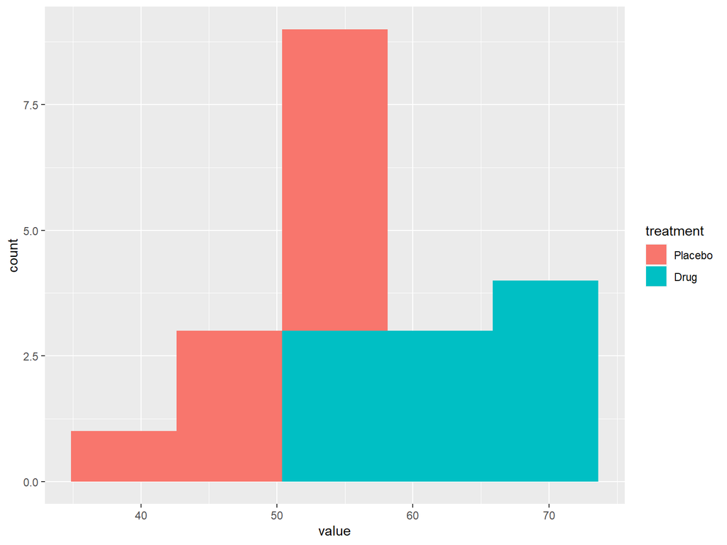

```r
ggplot(datamelt) + geom_histogram(mapping=aes(x=value,
                                              fill=treatment),
                                  bins=5)
```

# Sampling the population - Bootstrapping

- Let’s simulate randomly obtaining 10 measurements from the different samples.
- If we do this 10,000 times, we will see that the distribution of the average of the samples gives a normal distribution.
- In fact, the standard deviation of this distribution is called the Standard Error (SE).

```r
D_placebo=numeric()
D_drug= numeric()
set.seed(123)

n=10

for (i in 1:10000) {
  D_placebo[i] = mean(Placebo[sample(1:length(Placebo), n, replace=T)])
  D_drug[i] = mean(Drug[sample(1:length(Drug), n, replace=T)])
  }

D_datamelt = melt(cbind(D_placebo,D_drug),
                varnames = c("id","treatment"))
```

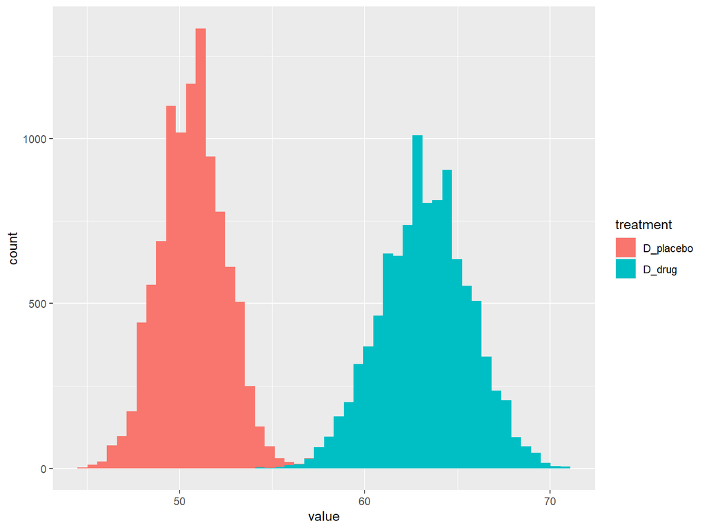

```r
ggplot(D_datamelt) +
  geom_histogram(mapping=aes(x=value, fill=treatment), bins=50)
```

# Standard error is sensitive to number of samples.

$$SE_{\bar{x}} = {\frac{\sigma}{\sqrt{n}}}$$

```r
D_placebo=numeric()
D_drug= numeric()
set.seed(123)

n=5
for (i in 1:10000) {
  D_placebo[i] = mean(Placebo[sample(1:length(Placebo), n, replace=T)])
  D_drug[i] = mean(Drug[sample(1:length(Drug), n, replace=T)])
  }

D_datamelt = melt(cbind(D_placebo,D_drug),
                varnames = c("id","treatment"))
```

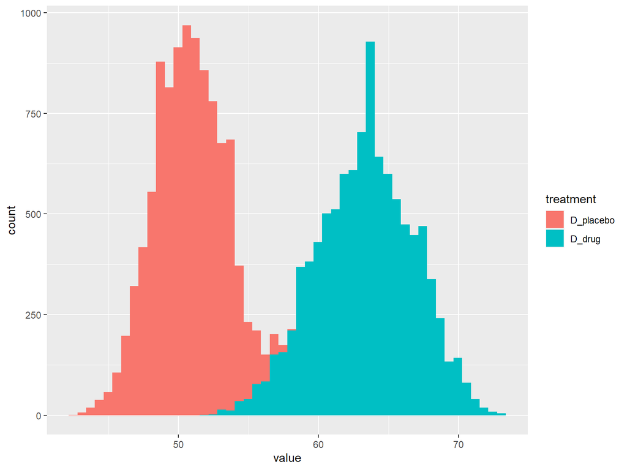

```r
ggplot(D_datamelt) +
  geom_histogram(mapping=aes(x=value, fill=treatment), bins=50)
```

# Difference of means is also normally distributed

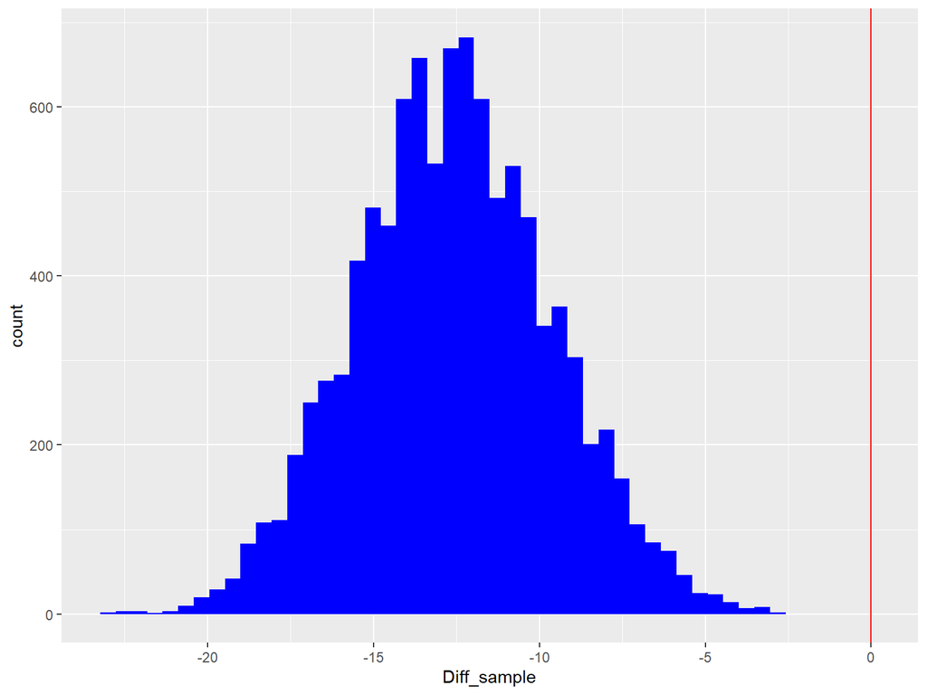

```r
ggplot() +
  geom_histogram(mapping=aes(x=Diff_sample), fill="blue", bins=50) +
  geom_vline(mapping=aes(xintercept=0), col="red")
```

# Shuffling for significance

```r
Diff_shuffle_sample = numeric()
set.seed(123)

datameltshuffle = datamelt
n=10
for (i in 1:10000) {
  datameltshuffle$value = sample(datamelt$value, nrow(datamelt),replace=F)

  # tapply function applies a function to a vector grouped by factor
  Diff_shuffle_sample[i] = diff(tapply(datameltshuffle$value,
                                    datameltshuffle$treatment,
                                       mean))
}
```

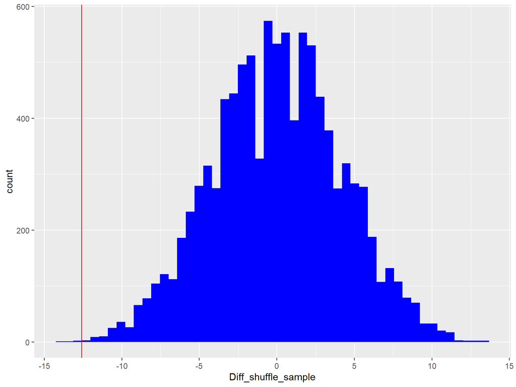

```r
ggplot() +
  geom_histogram(mapping=aes(x=Diff_shuffle_sample),
                 fill="blue", bins=50) +
  geom_vline(mapping=aes(xintercept=mean(Placebo)-mean(Drug)),
             col="red")
```

# The results

```r
sum(Diff_shuffle_sample <= (mean(Placebo)-mean(Drug)))/10000
```

```
## [1] 4e-04
```

```r
#confirmation using the t.test() function.
t.test(Placebo, Drug, var.equal = T)
```

```
##
##  Two Sample t-test
##
## data:  Placebo and Drug
## t = -4.0154, df = 18, p-value = 0.0008116
## alternative hypothesis: true difference in means is not equal to 0
## 95 percent confidence interval:
##  -19.192567  -6.007433
## sample estimates:
## mean of x mean of y
##      50.7      63.3
```